# Homework 1

Several of your friends live in Europe and are offered jobs in a US company with many locations all across the country. The job offers are great but news with headlines such as [**US Gun Homicide Rate Higher Than Other Developed Countries**](http://abcnews.go.com/blogs/headlines/2012/12/us-gun-ownership-homicide-rate-higher-than-other-developed-countries/) have theinm worried. Charts like this make them worry even more:

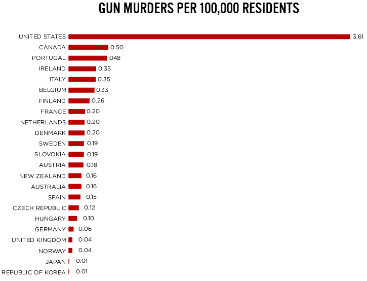

US gun homicides second chart

You want to convince your friends that the US is a large and diverse country with 50 very different states as well as the District of Columbia (DC). You want to recommend some state for each friend knowing that some like hiking, others would like to be close to several large cosmopolitan cities. Use data from the US murders data set:

```r
library(dslabs)
data(murders)
```

1. What is the state with the most murders? Would you say this is the most dangerous state? Hint: Make a plot showing the relationship between population size and number of murders.

**California** has the most murders. At this point, it’s unclear if California is the most dangerous state, because we are only looking at the raw number of murders vs. the total population. Murder rate would need to be calculated to determine this answer.

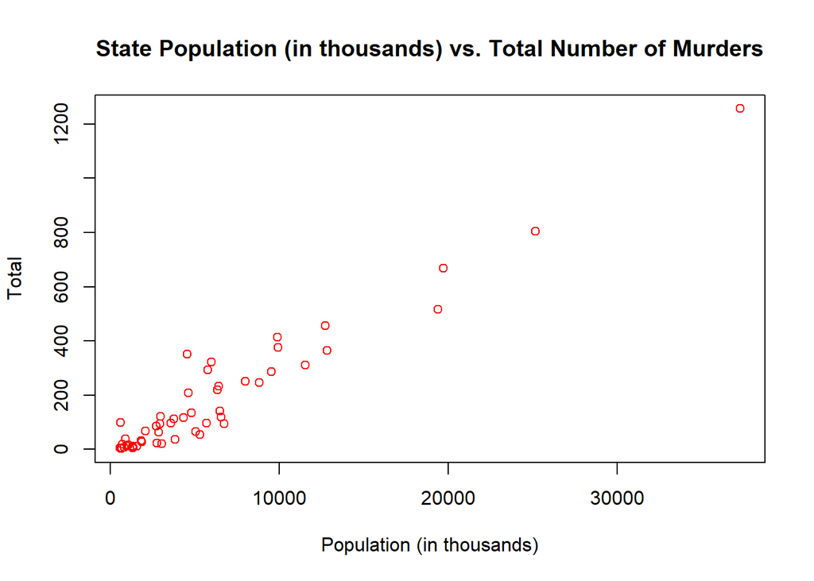

```r
murders$popscaled<- murders$population/1000

plot(murders$popscaled, murders$total, xlab='Population (in thousands)', ylab='Total', main='State Population (in thousands) vs. Total Number of Murders', col="red")
```

```r
sort(murders$total)
```

```
##  [1]    2    4    5    5    7    8   11   12   12   16   19   21   22   27
## [15]   32   36   38   53   63   65   67   84   93   93   97   97   99  111
## [29]  116  118  120  135  142  207  219  232  246  250  286  293  310  321
## [43]  351  364  376  413  457  517  669  805 1257
```

```r
order(murders$total)
```

```
##  [1] 46 35 30 51 12 42 20 13 27 40  2 16 45 49 28 38  8 24 17  6 32 29  4
## [24] 48  7 50  9 37 18 22 25  1 15 41 43  3 31 47 34 21 36 26 19 14 11 23
## [47] 39 33 10 44  5
```

```r
ind<-order(murders$total)
murders$abb[ind]
```

```
##  [1] "VT" "ND" "NH" "WY" "HI" "SD" "ME" "ID" "MT" "RI" "AK" "IA" "UT" "WV"
## [15] "NE" "OR" "DE" "MN" "KS" "CO" "NM" "NV" "AR" "WA" "CT" "WI" "DC" "OK"
## [29] "KY" "MA" "MS" "AL" "IN" "SC" "TN" "AZ" "NJ" "VA" "NC" "MD" "OH" "MO"
## [43] "LA" "IL" "GA" "MI" "PA" "NY" "FL" "TX" "CA"
```

```r
i_max<-which.max(murders$total)
murders$state[i_max]
```

```
## [1] "California"
```

```r
i_min<-which.min(murders$total)
murders$state[i_min]
```

```
## [1] "Vermont"
```

2. Add a column to the murder data table called `murder_rate` with each states murder rate.

```r
library(dplyr)
murders <- mutate(murders, murder_rate = total / population * 100000)
```

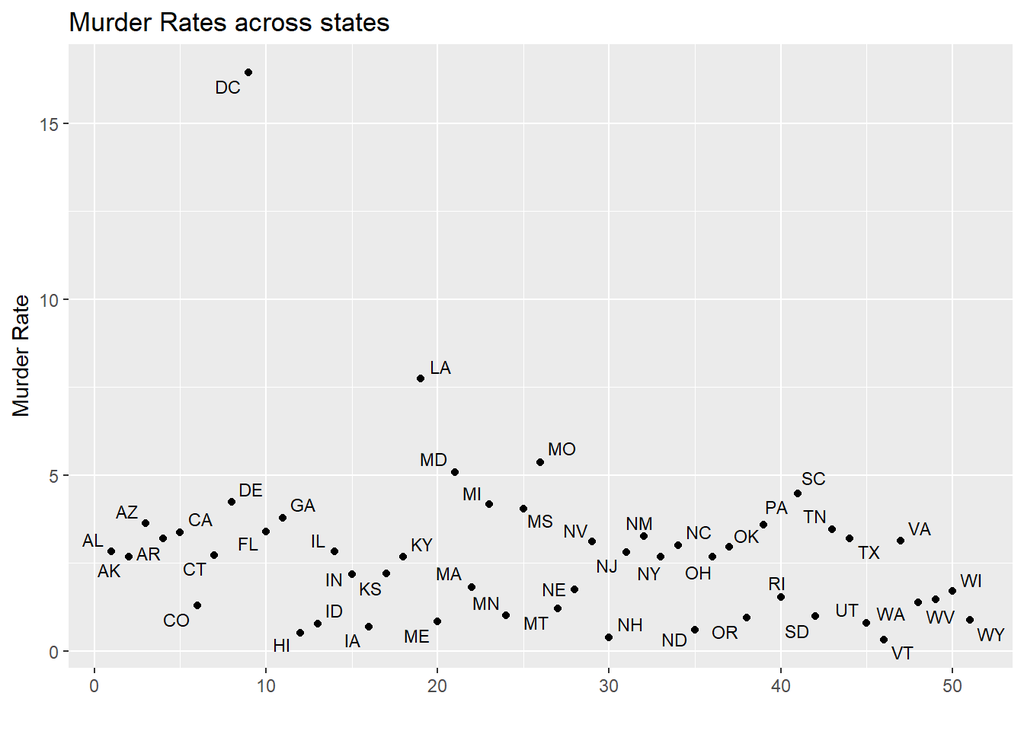

```r
library(ggplot2)
library(ggrepel)
ggplot(murders,
aes(y = murder_rate, x=seq_along(murder_rate))) +
geom_point() + geom_text_repel(aes(label=abb), size = 3)+
labs(title="Murder Rates across states",
         x="", y = "Murder Rate")
```

3. Describe the distribution of murder rates across states. How similar are states? How much do murder rates vary by geographical regions?

```r
filter(murders, murder_rate <= 0.71)
```

```
##           state abb        region population total popscaled murder_rate
## 1        Hawaii  HI          West    1360301     7  1360.301   0.5145920
## 2          Iowa  IA North Central    3046355    21  3046.355   0.6893484
## 3 New Hampshire  NH     Northeast    1316470     5  1316.470   0.3798036
## 4  North Dakota  ND North Central     672591     4   672.591   0.5947151
## 5       Vermont  VT     Northeast     625741     2   625.741   0.3196211
```

```r
filter(murders, murder_rate >=5)
```

```
##                  state abb        region population total popscaled
## 1 District of Columbia  DC         South     601723    99   601.723
## 2            Louisiana  LA         South    4533372   351  4533.372
## 3             Maryland  MD         South    5773552   293  5773.552
## 4             Missouri  MO North Central    5988927   321  5988.927
##   murder_rate
## 1   16.452753
## 2    7.742581
## 3    5.074866
## 4    5.359892
```

```r
i_max<-which.max(murders$murder_rate)
murders$state[i_max]
```

```
## [1] "District of Columbia"
```

When evaluating for murder rate, the answer to number one is much more clear. District of Columbia has the highest murder rate in the country: more than *double* the next closest state. While a dangerous city, it is still an interesting finding considering DC’s strict gun laws; although the mechanism of murder is not listed. (Additionally, since DC does not have statehood, Louisiana would technically be the most dangerous ‘state’.)

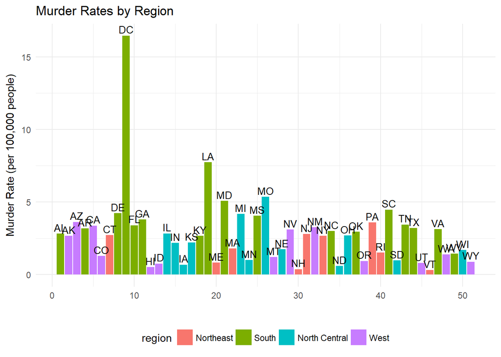

```r
ggplot(murders,
aes(x=seq_along(murder_rate), y=murder_rate, fill=region))+
geom_bar(stat="identity")+ theme_minimal()+
  geom_text(aes(label=abb), vjust=-0.3, size=3.5)+
  theme(legend.position="bottom")+
labs(title="Murder Rates by Region",
     y = "Murder Rate (per 100,000 people)",x="")
```

```r
murders %>% select(state, region, murder_rate) %>% filter(region=="West") %>% arrange(murder_rate)
```

```
##         state region murder_rate
## 1      Hawaii   West   0.5145920
## 2       Idaho   West   0.7655102
## 3        Utah   West   0.7959810
## 4     Wyoming   West   0.8871131
## 5      Oregon   West   0.9396843
## 6     Montana   West   1.2128379
## 7    Colorado   West   1.2924531
## 8  Washington   West   1.3829942
## 9      Alaska   West   2.6751860
## 10     Nevada   West   3.1104763
## 11 New Mexico   West   3.2537239
## 12 California   West   3.3741383
## 13    Arizona   West   3.6295273
```

```r
murders %>% select(state, region, murder_rate) %>% filter(region=="South") %>% arrange(murder_rate)
```

```
##                   state region murder_rate
## 1         West Virginia  South    1.457101
## 2              Kentucky  South    2.673201
## 3               Alabama  South    2.824424
## 4              Oklahoma  South    2.958934
## 5        North Carolina  South    2.999324
## 6              Virginia  South    3.124600
## 7              Arkansas  South    3.189390
## 8                 Texas  South    3.201360
## 9               Florida  South    3.398069
## 10            Tennessee  South    3.450936
## 11              Georgia  South    3.790323
## 12          Mississippi  South    4.044085
## 13             Delaware  South    4.231937
## 14       South Carolina  South    4.475323
## 15             Maryland  South    5.074866
## 16            Louisiana  South    7.742581
## 17 District of Columbia  South   16.452753
```

```r
murders %>% select(state, region, murder_rate) %>% filter(region=="Northeast") %>% arrange(murder_rate)
```

```
##           state    region murder_rate
## 1       Vermont Northeast   0.3196211
## 2 New Hampshire Northeast   0.3798036
## 3         Maine Northeast   0.8280881
## 4  Rhode Island Northeast   1.5200933
## 5 Massachusetts Northeast   1.8021791
## 6      New York Northeast   2.6679599
## 7   Connecticut Northeast   2.7139722
## 8    New Jersey Northeast   2.7980319
## 9  Pennsylvania Northeast   3.5977513
```

```r
murders %>% select(state, region, murder_rate) %>% filter(region=="North Central") %>% arrange(murder_rate)
```

```
##           state        region murder_rate
## 1  North Dakota North Central   0.5947151
## 2          Iowa North Central   0.6893484
## 3  South Dakota North Central   0.9825837
## 4     Minnesota North Central   0.9992600
## 5     Wisconsin North Central   1.7056487
## 6      Nebraska North Central   1.7521372
## 7       Indiana North Central   2.1900730
## 8        Kansas North Central   2.2081106
## 9          Ohio North Central   2.6871225
## 10     Illinois North Central   2.8369608
## 11     Michigan North Central   4.1786225
## 12     Missouri North Central   5.3598917
```

```r
us_murder_rate <- murders %>%
  summarize( murder_rate= sum(total) / sum(population) * 100000) %>%
  .$murder_rate

us_murder_rate
```

```
## [1] 3.034555
```

Compared to the murder rates across entire regions:

```r
murders %>%
  group_by(region) %>%
  summarize(avg_murder_rate= mean(sum(total) / sum(population) * 100000))
```

```
## # A tibble: 4 x 2
##          region avg_murder_rate
##          <fctr>           <dbl>
## 1     Northeast        2.655592
## 2         South        3.626558
## 3 North Central        2.731334
## 4          West        2.656175
```

Yet, let’s also look at the means for region murder rates when weighing each state equally (rather than total murders and populations of regions):

```r
murders %>%
  group_by(region) %>%
  summarize(avg_of_murder_rates= mean(murder_rate), variance=var(murder_rate))
```

```
## # A tibble: 4 x 3
##          region avg_of_murder_rates  variance
##          <fctr>               <dbl>     <dbl>
## 1     Northeast            1.847500  1.378477
## 2         South            4.417012 11.376348
## 3 North Central            2.182040  2.069729
## 4          West            1.833401  1.373954
```

It is evident that there is definitely an increase in murders in the South compared to the rest of the country. Once you dive into the South though, you can see that the variance is *very* high for the different murder rates across states in that region. Looking at the summarized data for the south, there are 5 states (West Virginia, Kentucky, Alabama, Oklahoma and North Carolina) that have murder rates below the national average. However, from the boxplot of murder rates in the south, the two upper outliers (LA and DC) are pulling up the average quite a bit.

Even though the West has the lowest average murder rates (when weighing each state equally), Nevada, New Mexico, California and Arizona all have murder rates above the US murder rate.

Comparing variance with the entire country:

```r
var(murders$murder_rate)
```

```
## [1] 6.032518
```

We can further evaluate by making histograms and box plots of murder rates for the entire country, and then by region:

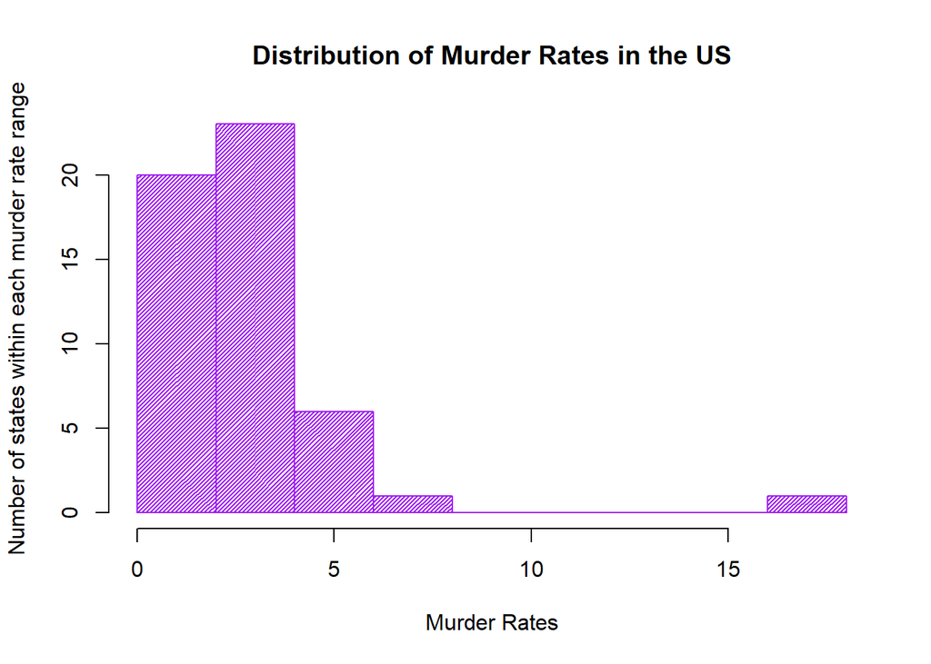

```r
NC <-murders$region=="North Central"
W <-murders$region=="West"
S <-murders$region=="South"
NE <-murders$region=="Northeast"


hist(murders$murder_rate, col= "purple", density = 45, main = "Distribution of Murder Rates in the US", xlab = "Murder Rates", ylab="Number of states within each murder rate range")
```

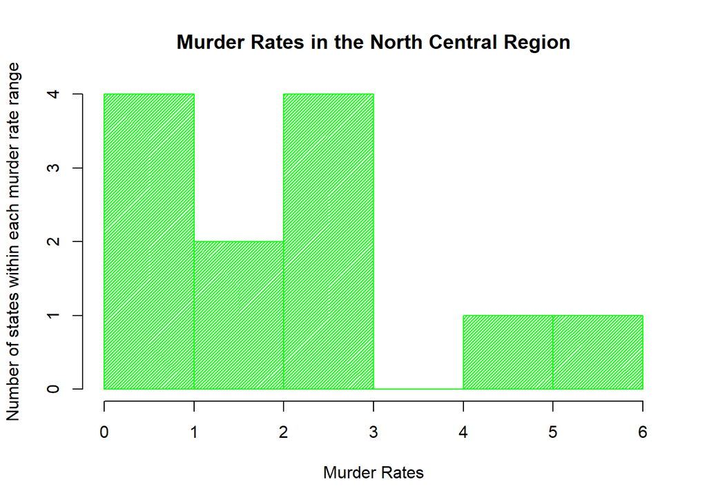

```r
hist(murders$murder_rate[NC], col= "green", density = 45, main = "Murder Rates in the North Central Region", xlab = "Murder Rates", ylab="Number of states within each murder rate range")
```

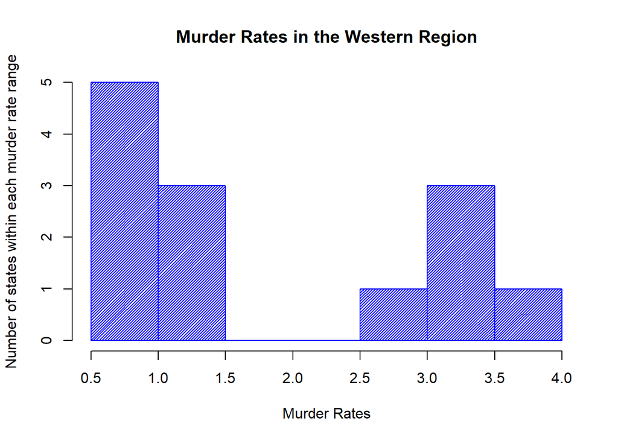

```r
hist(murders$murder_rate[W], col= "blue", density = 45, main = "Murder Rates in the Western Region", xlab = "Murder Rates", ylab="Number of states within each murder rate range")
```

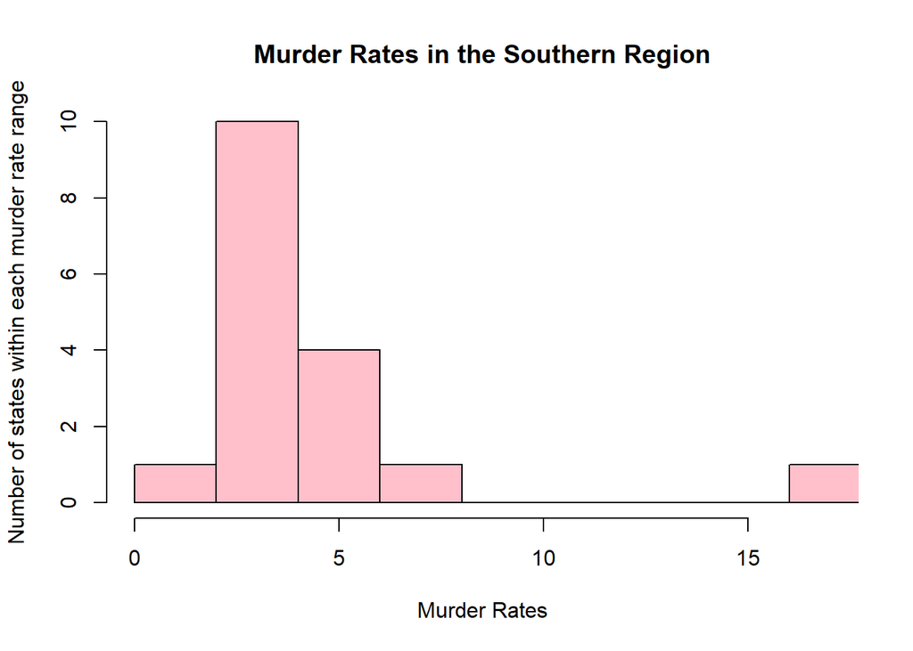

```r
hist(murders$murder_rate[S], breaks=10, col= "pink", main = "Murder Rates in the Southern Region", xlim=c(0,17), xlab = "Murder Rates", ylab="Number of states within each murder rate range")
```

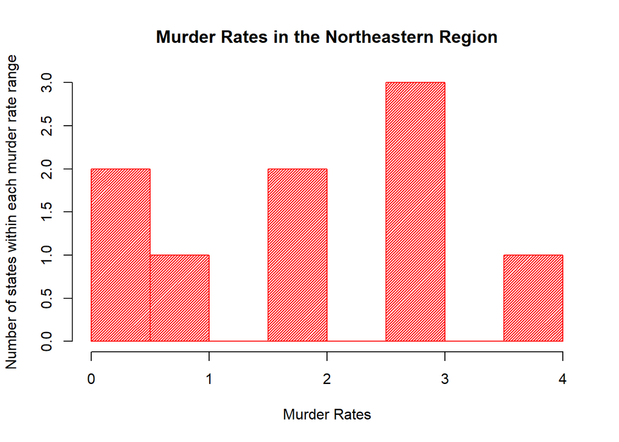

```r
hist(murders$murder_rate[NE], col= "red", density = 45, main = "Murder Rates in the Northeastern Region", xlab = "Murder Rates", ylab="Number of states within each murder rate range")
```

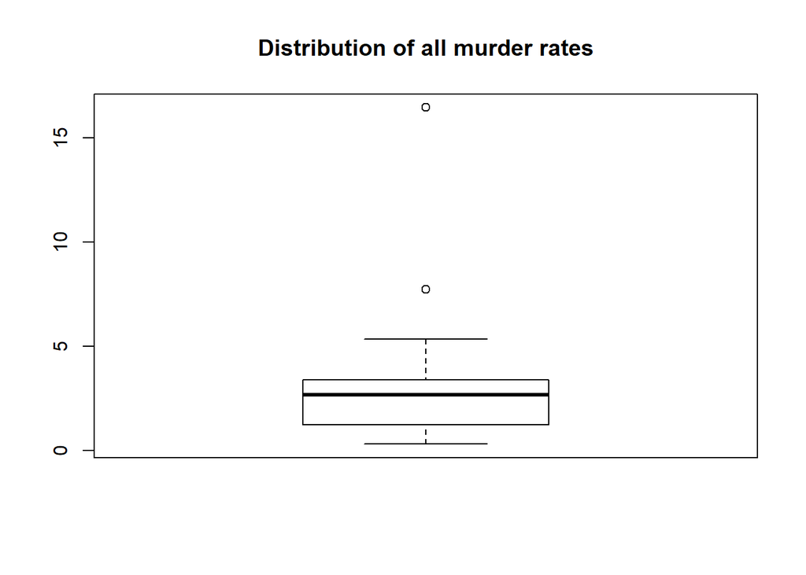

```r
boxplot(murders$murder_rate, main = "Distribution of all murder rates")
```

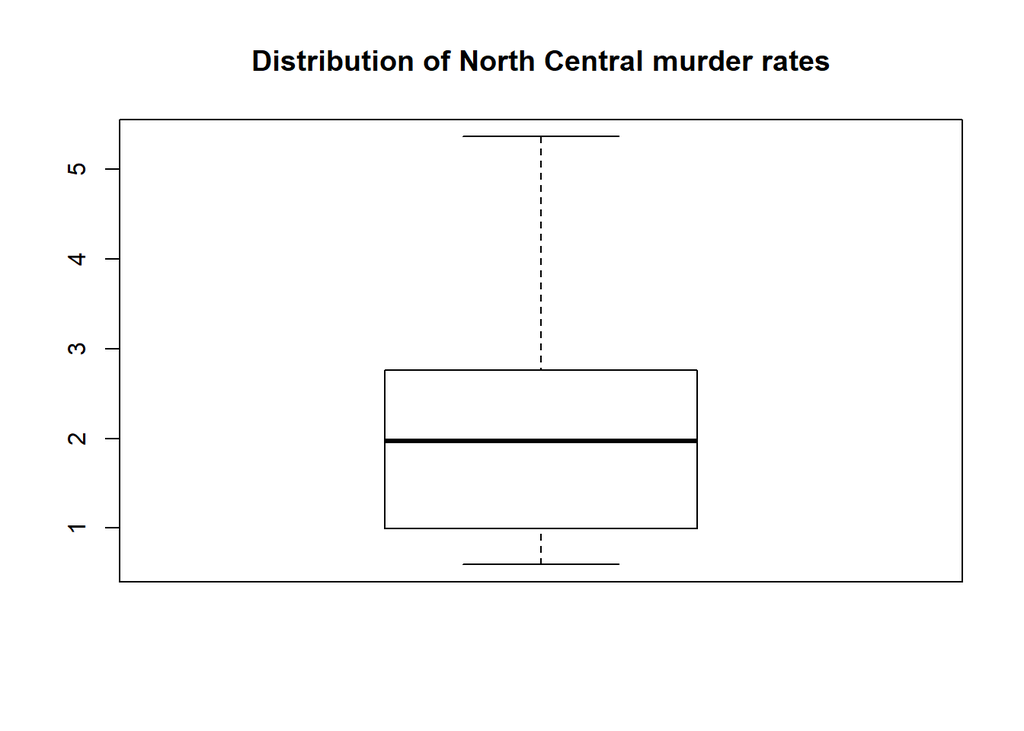

```r
boxplot(murders$murder_rate[NC], main = "Distribution of North Central murder rates")
```

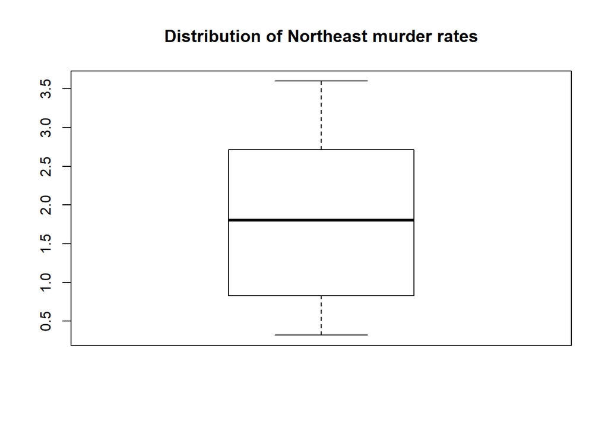

```r
boxplot(murders$murder_rate[NE],main = "Distribution of Northeast murder rates")
```

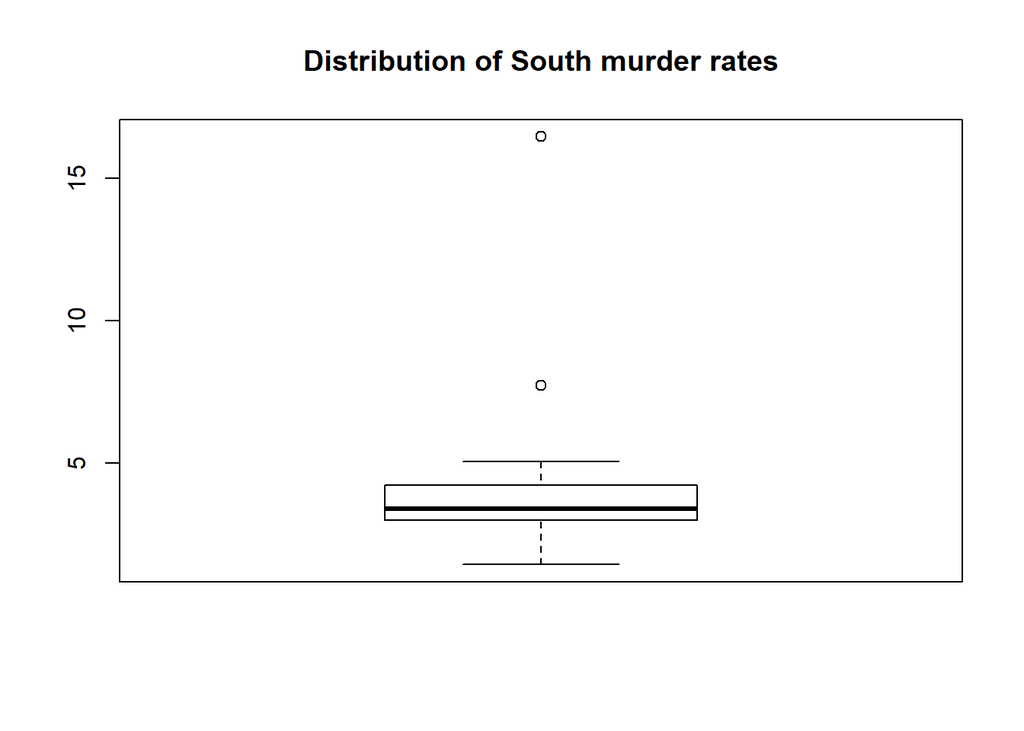

```r
boxplot(murders$murder_rate[S], main = "Distribution of South murder rates")
```

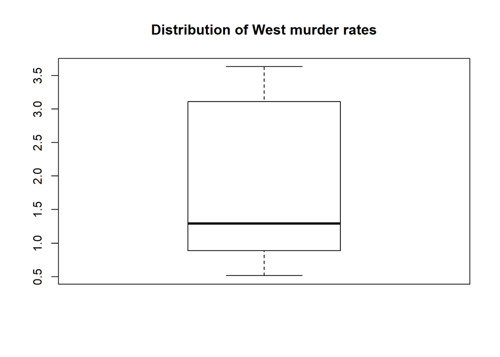

```r
boxplot(murders$murder_rate[W], main = "Distribution of West murder rates")
```

4. Write a report for your friends reminding them that the US is a large and diverse country with 50 very different states as well as the District of Columbia (DC). Suppose one of your friends loves hiking, one wants to live in a warm climate, and another would like to be close to several large cosmopolitan cities. Recommend a desirable state for each friend.

## Chosing a place to live in the United States

While the U.S. murder rate can be a bit concerning when comparing to other countries, just remember that the U.S. is a very large country, and there are many safe places to live! Looking at the information above, while the South has the highest murder rates in the country, there are still many safe and wonderful places to live there! Additionally, while the West has the lowest in the country, it’s still best to examine the information before picking a state from that region at random.

Above, I’ve calculated the murder rates for the each state in the United States, and compared them across the entire country and by region. 20 states in the U.S. have a murder rate less than 2; and the safest state, Vermont, has a murder rate less than Belgium, Portugal, Ireland, Italy, and Canada. While the second safest state, New Hampshire, is less than Canada and Portugal.

#### Best Place to live for hiking

If hiking and outdoors are the main interest, the West is likely where you want to live! Based on that, I would recommend the following states for their wonderful hiking (and safety!):

- Hawaii (murder rate of 0.51)
- Idaho (murder rate of 0.77)

I listed two here depending on the type of weather you enjoy. Hawaii is great for hiking year round, but Idaho has great hiking in the summer, and skiing in the winter!

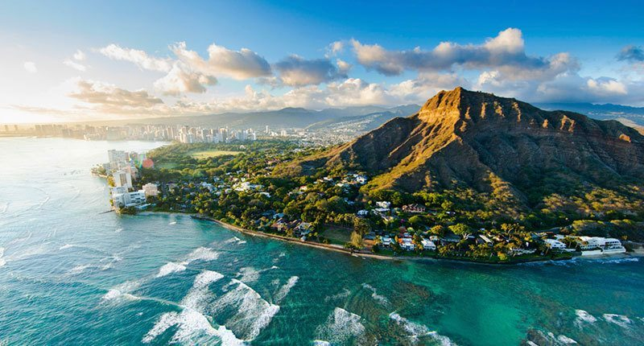

Hawaii

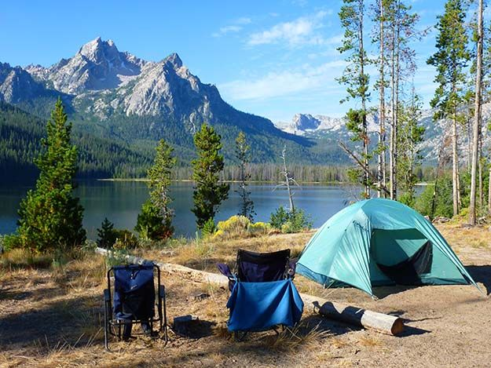

Idaho

[This website](http://www.fodors.com/news/photos/10-most-beautiful-hikes-in-the-us) has the best hikes in the U.S., yet it really depends on the type of hiking and weather you enjoy.

#### Best place to live for a warm climate

If you would like to live in a warm climate, I recommend the South. Despite it’s high murder rate, there are many great places to live there! DC and Louisiana both have murder rates that are outliers for the region, and are a big reason why the murder rate in the South is so high! If you look at the box plot and histograms for the South above, you can see the large variance in the rates among those states.

Depending where in the South you are, the climate can change pretty drastically. While West Virginia has the lowest murder rate, it gets a lot colder than other states.

In this case, I would recommend Alabama or Kentucky. Both states have warm climates (Alabama is a little warmer), and are the safer of the southern states.

However, if moving away from the south, I would again suggest Hawaii! It has a wonderful climate and is incredibly safe.

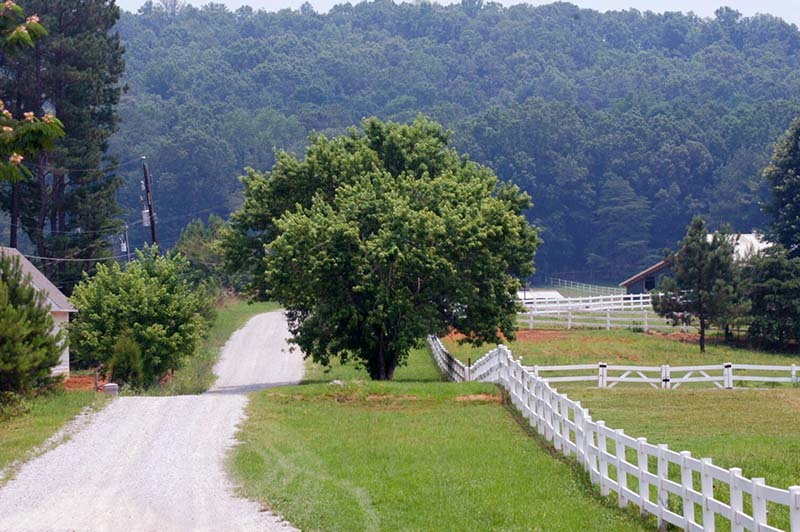

Alabama

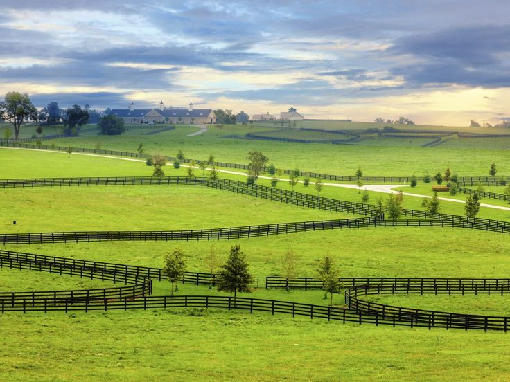

Kentucky

#### Best place to live with city access

If being close to several metropolitian areas is the main focus, the Northeast is your best option! There are many cities very close together, and each one is unique and great in it’s own way (even the dangerous city of DC).

While Vermont and New Hampshire are the safest cities in this region, the are not that close to the major cities. Looking at a map of the Northeast, I would actually recommend New York! It’s not the safest one list, but it’s below the national average and incredibly convenient if you want to hop between cities on the East coast!

[figure not shown]

Map of Northeast

In general, living closer to cosmopolitan cities is likely to have higher murder rates in general, but living in the state of New York, and not directly in NYC will offer an incredibly safe and great place to live!

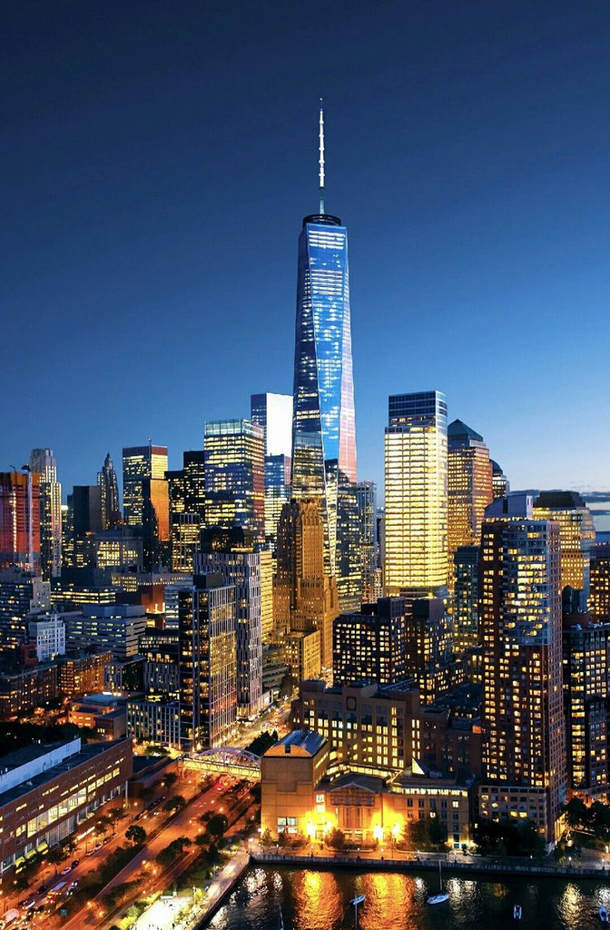

New York City